# Отчет по лабораторной работе №1

Операционные системы

Бельчуг Александр Константинович

# Цель работы

Целью данной работы является приобретение практических навыков установки операционной системы на виртуальную машину, настройки минимально необходимых для дальнейшей работы сервисов.

# Задание

1. Создание виртуальной машины
2. Установка операционной системы
3. Работа с операционной системой после установки
4. Установка программного обеспечения для создания документации
5. Дополнительные задания

# Выполнение лабораторной работы

## Создание виртуальной машины

Virtualbox я устанавливала и настраивала при выполнении лабораторной работы в курсе “Архитектура компьютера и Операционные системы (раздел”Архитектура компьютера”)“, поэтому сразу открываю окно приложения (рис. @fig:001).

[figure not shown]

Окно Virtualbox

Нажимая “создать”, создаю новую виртуальную машину, указываю ее имя, путь к папке машины по умолчанию меня устраивает, выбираю тип ОС и версию (рис. @fig:002).

[figure not shown]

Создание виртуальной машины

Указываю объем основной памяти виртуальной машины размером 4096МБ (рис. @fig:003).

[figure not shown]

Указание объема памяти

Выбираю создание нового виртуального жесткого диска (рис. @fig:004).

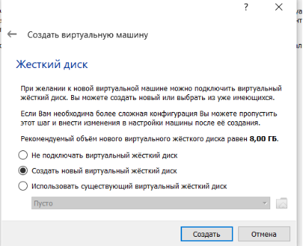

Жесткий диск

Задаю конфигурацию жесткого диска: загрузочеый VDI (рис. @fig:005).

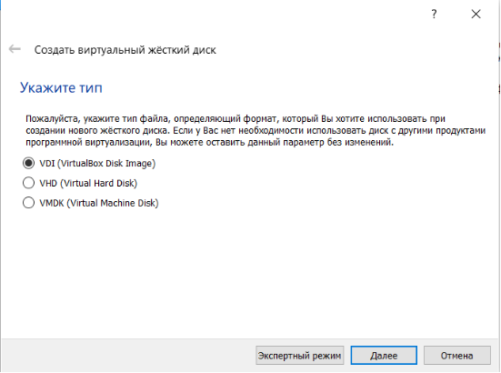

Тип жесткого диска

Задаю размер диска - 80 ГБ, оставляю расположение жесткого диска по умолчанию, т. к. работаю на собственной технике и значение по умолчанию меня устраивает (рис. @fig:006).

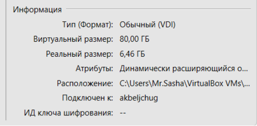

Размер жесткого диска

Выбираю динамический виртуальный жесткого диска при указании формата хранения (рис. @fig:007).

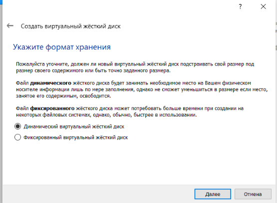

Формат хранения жесткого диска

Выбираю в Virtualbox настройку своей виртуальной машины. Перехожу в “Носители”, добавляю новый привод привод оптических дисков и выбираю скачанный образ операционной системы Fedora (рис. @fig:008).

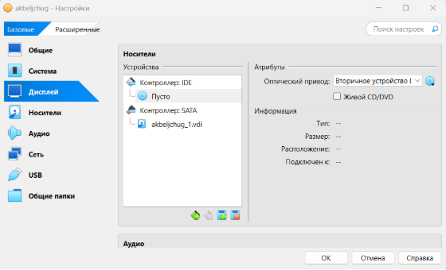

Выбор образа оптического диска

Скачанный образ ОС был успешно выбран (рис. @fig:009).

[figure not shown]

Выбранный образ оптического диска

## Установка операционной системы

Запускаю созданную виртуальную машину для установки (рис. @fig:010).

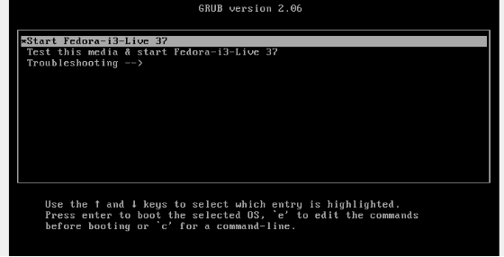

Окно загрузчика

[figure not shown]

Нажимаю Win+Enter для запуска терминала. В терминале запускаю liveinst (рис. @fig:012).

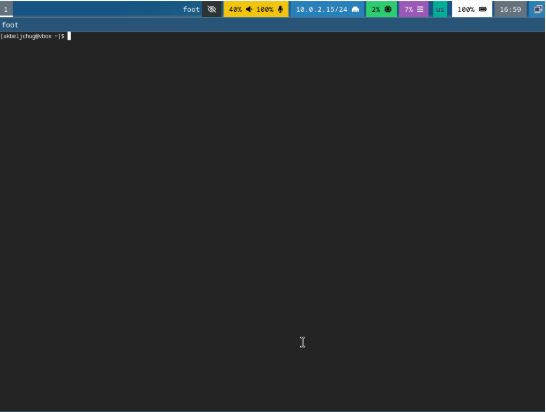

Запуск терминала

Чтобы перейти к раскладке окон с табами, нажимаю Win+w. Выбираю язык для использования в процессе установки русски (рис. @fig:013).

[figure not shown]

Выбор языка интерфейса

Раскладку клавиатуры выбираю и русскую, и английскую (рис. @fig:014).

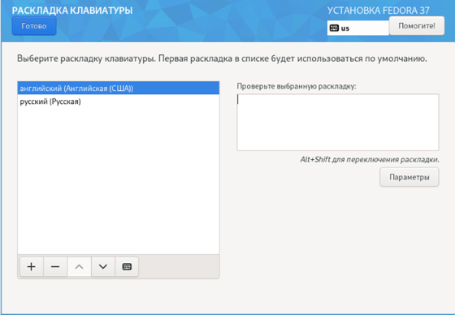

Выбор раскладки клавиатуры

Проверяю место установки и сохраняю значение по умолчанию (рис. @fig:016).

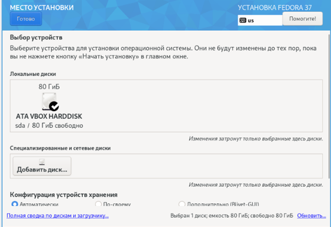

Выбор места установки

Создаю аккаунт администратора и создаю пароль для супер-пользователя (рис. @fig:018).

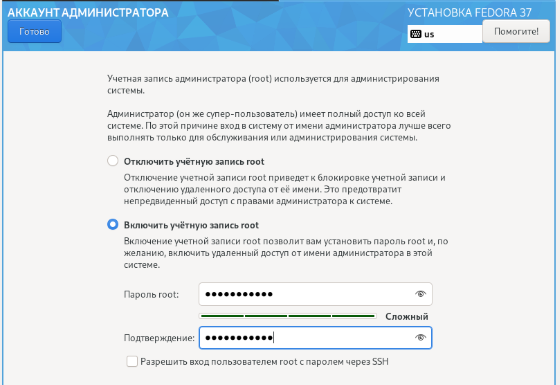

Создание аккаунта администратора

## Работа с операционной системой после установки

[figure not shown]

[figure not shown]

Устанавливаю программы для автоматического обновления (рис. @fig:027).

[figure not shown]

Запускаю таймер (рис. @fig:028).

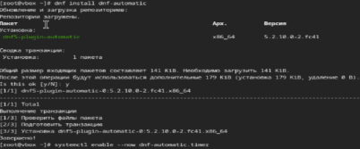

Запуск таймера

[figure not shown]

[figure not shown]

[figure not shown]

[figure not shown]

[figure not shown]

Отредактируйте конфигурационный файл (рис. @fig:035).

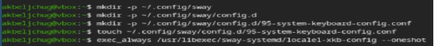

Отредактируйте конфигурационный файл

[figure not shown]